# Bulk RNA-seq analysis for Modeling drug responses and evolutionary dynamics using triple negative breast cancer patient-derived xenografts

# Content

Here you will find the code that was used to analyse bulk RNA-seq data for [Modeling drug responses and evolutionary dynamics using triple negative breast cancer patient-derived xenografts](https://doi.org/10.1101/2023.01.10.523259). To reproduce the figures please use the provided inputs in this repo.

Input files will be at the data folder. The chunks are setup to run the code from the repo folder.

# Methods

Bulk RNA-seq expression data was produced aligning with (STAR)[https://www.ncbi.nlm.nih.gov/pmc/articles/PMC3530905/] and quantifying with (salmon)[https://www.nature.com/articles/nmeth.4197].

The bioinformatics analysis of the RNA-seq data was perform using R 4.0.3. Gene Set Enrichment Analysis (GSEA) was done in single-sample mode ((ssGSEA)[https://gsea-msigdb.github.io/ssGSEA-gpmodule/v10/index.html]) with the (GSVA)[https://bmcbioinformatics.biomedcentral.com/articles/10.1186/1471-2105-14-7] package and [fgsea](https://www.biorxiv.org/content/10.1101/060012v3) package for pathway analysis. Normalization and differential gene expression analysis was done using [edgeR](https://www.ncbi.nlm.nih.gov/pmc/articles/PMC2796818/) package.

# Setup

Please make sure you have all required packages installed. If you are starting from scratch we recommend installing (`mamba`)[https://mamba.readthedocs.io/en/latest/installation/mamba-installation.html] and using our (`yaml` file)[yaml/bulkrnaseqpdx.yml] folder with all the required packages to run this code:

```bash
# Create environment
mamba env create --file yaml/bulkrnaseqpdx.yml
# activate environment
mamba activate bulkrnapdx
# Re-run this R notebook to obtain HTML or open in Rstudio to work on it interactively
Rscript -e "rmarkdown::render('BulkRNASeq_Analysis.Rmd')"
```

After activating mamba environment you will obtain an HTML file with the bulk RNA-seq plots used for the paper.

```r
library(edgeR)
library(data.table)
library(ggfortify)
```

```r
library(cowplot)
library(ggplot2)
library(ComplexHeatmap)
library(ggsci)
library(GSVA)
library(GSEABase)
library(ggpubr)
library(ggbeeswarm)
library(DESeq2)
library(RColorBrewer)
library(fgsea)
```

# Figure 1C: A preclinical platform of triple-negative breast cancer (TNBC) patient-derived tumour xenografts (PDTXs).

## Preparation of passage table

```r
passage.table <- data.table(Model=c(rep("PAR1006", 6),
                                    rep("PAR1022", 6),
                                    rep("PAR1040", 6),
                                    rep("PAR1141", 6)),
                            Type=rep(c(rep("SpatialRegion", 2),
                                   rep("SisterMice", 2),
                                   rep("BetweenPassages", 2)), 4),
                            SampleNr=rep(rep(c(1,2),3), 4),
                            SampleID=c("PAR1006-T1-P03-19.037998-T1-FF1", "PAR1006-T1-P03-19.037998-T1-FF3",
                                       "PAR1006-T1-P02-18.018211-T1-FF1", "PAR1006-T1-P02-18.018213-T1-FF1",
                                       "PAR1006-T1-P02-18.018211-T1-FF1", "PAR1006-T1-P03-19.038002-T1-FF1",
                                       "PAR1022-T1-P02-18.018165-T1-FF1", "PAR1022-T1-P02-18.018165-T1-FF3",
                                       "PAR1022-T1-P03-18.028981-T1-FF1", "PAR1022-T1-P03-18.028983-T1-FF1",
                                       "PAR1022-T1-P02-18.018183-T1-FF1", "PAR1022-T1-P03-18.028981-T1-FF1",
                                       "PAR1040-T1-P02-18.018227-T1-FF1", "PAR1040-T1-P02-18.018227-T1-FF3",
                                       "PAR1040-T1-P01-17.044996-T1-FF1", "PAR1040-T1-P01-17.045005-T1-FF2",
                                       "PAR1040-T1-P01-17.044996-T1-FF1", "PAR1040-T1-P02-18.018155-T1-FF1",
                                       "PAR1141-T1-P01-18.036674-T1-FF1", "PAR1141-T1-P01-18.036674-T1-FF3",
                                       "PAR1141-T1-P02-19.023968-T1-FF1", "PAR1141-T1-P02-19.023970-T1-FF1",
                                       "PAR1141-T1-P01-18.045501-T1-FF1", "PAR1141-T1-P02-19.023968-T1-FF1"))
passage.table$idx <- 1:nrow(passage.table)
passage.table
```

| Model | Type | SampleNr | SampleID | idx |
| --- | --- | --- | --- | --- |
| PAR1006 | SpatialRegion | 1 | PAR1006-T1-P03-19.037998-T1-FF1 | 1 |
| PAR1006 | SpatialRegion | 2 | PAR1006-T1-P03-19.037998-T1-FF3 | 2 |
| PAR1006 | SisterMice | 1 | PAR1006-T1-P02-18.018211-T1-FF1 | 3 |
| PAR1006 | SisterMice | 2 | PAR1006-T1-P02-18.018213-T1-FF1 | 4 |
| PAR1006 | BetweenPassages | 1 | PAR1006-T1-P02-18.018211-T1-FF1 | 5 |
| PAR1006 | BetweenPassages | 2 | PAR1006-T1-P03-19.038002-T1-FF1 | 6 |
| PAR1022 | SpatialRegion | 1 | PAR1022-T1-P02-18.018165-T1-FF1 | 7 |
| PAR1022 | SpatialRegion | 2 | PAR1022-T1-P02-18.018165-T1-FF3 | 8 |
| PAR1022 | SisterMice | 1 | PAR1022-T1-P03-18.028981-T1-FF1 | 9 |
| PAR1022 | SisterMice | 2 | PAR1022-T1-P03-18.028983-T1-FF1 | 10 |

[output cut: 14 more lines]

## Loading expression data

We look at untreated samples and expect clustering between PARTNER models which are: PAR1006, PAR1008, PAR1022, PAR1040, PAR1053, PAR1141, PAR1177 and PAR1221.

```r
load('data/PDXModDynTNBC_MetaUntreated.Rdata')
load('data/PDXModDynTNBC_ExprUntreated.Rdata')
# Check that metadata and expression data have same ids.
stopifnot(all(colnames(untreated.expr)==untreated.mdata$`Sample name`))
```

We select for coding genes. This list includes a few non-coding genes that have been identify in cancer studies.

```r
coding <- fread("data/gencode.v39.chr_patch_hapl_scaff.annotation.genes.coding.ensembl.txt", header = F)
# ignore PAR_Y genes (pseudoautosomal regions (PAR) from chromosome Y)
coding             <- coding[!coding$V1%like%"PAR_Y",]
nrow.before.coding <- nrow(untreated.expr)
# filter for coding in expression table
untreated.expr     <- untreated.expr[coding$V1,]
nrow.after.coding  <- nrow(untreated.expr)
message("We removed ", prettyNum(nrow.before.coding-nrow.after.coding, big.mark = ","), " noncoding genes from the analysis and kept ",prettyNum(nrow.after.coding, big.mark = ","), " coding genes.")
```

```
## We removed 0 noncoding genes from the analysis and kept 24,200 coding genes.
```

Finally, we normalise with edgeR and voom.

```r
# transform to edgeR object
m1 <- DGEList(untreated.expr)
# effective library size correction
m1 <- calcNormFactors(m1)
# transform data to microarray-like (log transform) with voom
untreated.expr.norm <- voom(m1)$E
```

## ssGSEA analysis

```r
hallmarks <- getGmt("~/Downloads/h.all.v7.5.1.symbols.gmt")
cancer.c6 <- getGmt("~/Downloads/c6.all.v7.5.1.symbols.gmt")
```

To use GSVA we need to convert our ENSEMBL ids to SYMBOLs:

```r
# read table with ensemblids and symbols
gene.names <- fread("data/gencode.v39.chr_patch_hapl_scaff.annotation.genetype.txt", header = F)
# provide appropriate colnames
colnames(gene.names)     <- c("symbol", "ensemblid", "type")
gene.names.vector        <- gene.names$symbol
names(gene.names.vector) <- gene.names$ensemblid
# convert ENSEMBL to SYMBOL
genes                         <- rownames(untreated.expr.norm)
rownames(untreated.expr.norm) <- gene.names.vector[genes]
```

Run GSEA in ssGSEA mode for (hallmarks)[https://www.gsea-msigdb.org/gsea/msigdb/human/collections.jsp#H] and (collection 6)(https://www.gsea-msigdb.org/gsea/msigdb/human/collections.jsp#C6) from (MsigDB)[https://www.gsea-msigdb.org/gsea/msigdb/].

```r
# Hallmarks
hallmarks.res <- gsva(expr = untreated.expr.norm,
                   gset.idx.list = hallmarks,
                   method = "ssgsea", verbose=TRUE)
```

```
## Estimating ssGSEA scores for 50 gene sets.
##
```

```r
stopifnot(all(colnames(hallmarks.res) == untreated.mdata$`Sample name`))
# C6
c6.res <- gsva(expr = untreated.expr.norm,
                   gset.idx.list = cancer.c6,
                   method = "ssgsea", verbose=TRUE)
```

```
## Estimating ssGSEA scores for 189 gene sets.
##
```

```r
stopifnot(all(colnames(c6.res) == untreated.mdata$`Sample name`))
```

Now, we get the enrichment scores from the GSEA analysis and generate a table for plotting:

```r
# Extraction of enrichment score to table
hallmarks.dt <- melt(hallmarks.res)
colnames(hallmarks.dt) <- c("PATHWAY", "SampleID", "Enrichment")
hallmarks.dt$Collection <- "HALLMARKS"
c6.dt <- melt(c6.res)
```

```r
colnames(c6.dt) <- c("PATHWAY", "SampleID", "Enrichment")
c6.dt$Collection <- "C6"
pathway.dt <- as.data.table(rbind(hallmarks.dt, c6.dt))
# Generation of table for plotting
generate.plotting.table <- function(x){
passage.plotting <- data.table()
for (idx in passage.table[SampleNr==1 & Type==x]$idx) {
  samplemodel <- passage.table$Model[idx]
  sampletype <- passage.table$Type[idx]
  sampleid1 <- passage.table[Model==samplemodel & Type==sampletype & SampleNr==1]$SampleID
  sampleid2 <- passage.table[Model==samplemodel & Type==sampletype & SampleNr==2]$SampleID
  sample1.pathways1 <- pathway.dt[SampleID==sampleid1][order(PATHWAY)]
  sample2.pathways1 <- pathway.dt[SampleID==sampleid2][order(PATHWAY)]
  stopifnot(sample1.pathways1$PATHWAY==sample2.pathways1$PATHWAY)
  tmp.dt <- data.table(Model=samplemodel, Type=sampletype,
                       Passage1=sample1.pathways1$Enrichment,
                       Passage2=sample2.pathways1$Enrichment,
                       Pathway=sample1.pathways1$PATHWAY,
                       Collection=sample1.pathways1$Collection)
  passage.plotting <- rbind(passage.plotting, tmp.dt)
}
passage.plotting
}
```

For the generation of plotting table I used the index of samples that were “sample 1” to iterate through the table with the mice to compare against “sample 2”.

### Figure 1 C

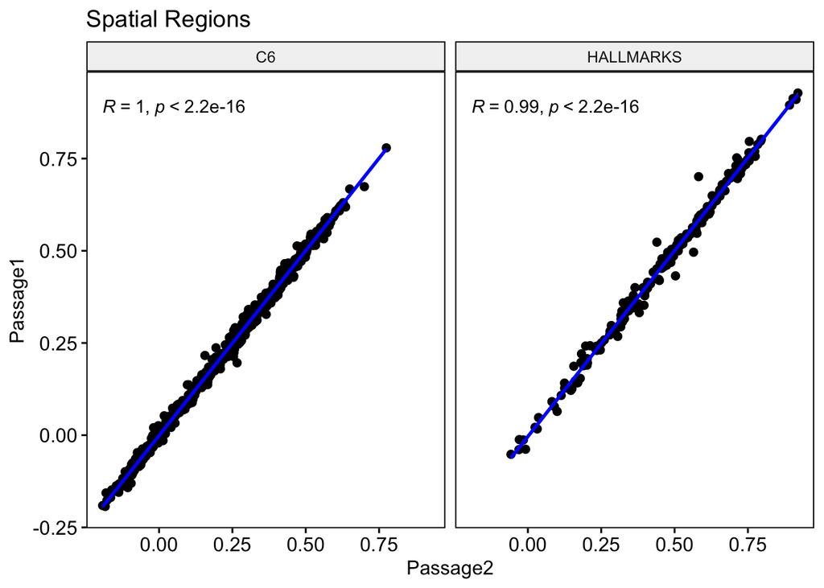

```r
# Plot comparing samples that were from the same model but different spatial regions:
ggscatter(generate.plotting.table("SpatialRegion"), x="Passage2", y="Passage1",
          add = "reg.line",                                 # Add regression line
          conf.int = TRUE,
          facet.by = "Collection",
          # Add confidence interval
          add.params = list(color = "blue",
                            fill = "lightgray")
          )+
  stat_cor(method = "spearman") + ggtitle("Spatial Regions")
```

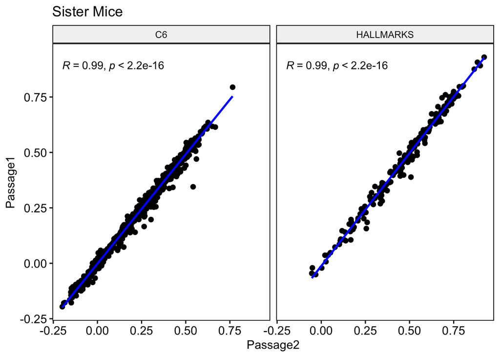

```r
# Plot comparing samples that were from the same model but different mice (sisters).:
ggscatter(generate.plotting.table("SisterMice"), x="Passage2", y="Passage1",
          add = "reg.line",                                 # Add regression line
          conf.int = TRUE,
          facet.by = "Collection",
          # Add confidence interval
          add.params = list(color = "blue",
                            fill = "lightgray")
          )+
  stat_cor(method = "spearman") +
  ggtitle("Sister Mice")
```

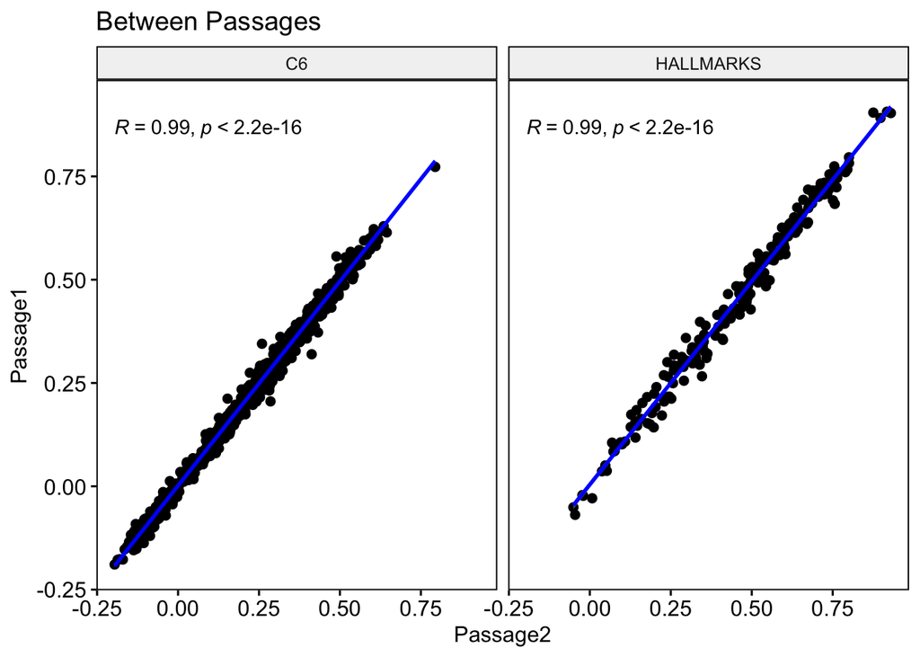

```r
# Plot comparing samples that were from the same model but different passages:
ggscatter(generate.plotting.table("BetweenPassages"), x="Passage2", y="Passage1",
          add = "reg.line",                                 # Add regression line
          conf.int = TRUE,
          facet.by = "Collection",
          # Add confidence interval
          add.params = list(color = "blue",
                            fill = "lightgray")
          )+
  stat_cor(method = "spearman") + ggtitle("Between Passages")
```

# Figure 5A and 5B:Olaparib treatment causes permanent phenotypic changes due to transcription factor reprogramming.

Heatmap displaying z score (scaled by row) of the top 250 strong and variable genes in PDTX samples.

Clustering analysis performed using Euclidean distances. Columns indicate samples. T: Treated. PT: Post-treated

```r
load("data/PDXModDynTNBC_ExprTrial.Rdata")
load("data/PDXModDynTNBC_MetaTrial.Rdata")
```

## Figure 5A

Select for strongly expressed genes with high variation using logCPM transformation.

```r
logcpm <- cpm(trial.expr, log=TRUE)
# highly express genes
strong_genes <- apply(logcpm, 1, mean)
# I am taking a bigger selection to increase the overlap
select_strong_5000 <- names(sort(strong_genes, decreasing=TRUE))[1:5000]
# highly variable genes
var_genes <- apply(logcpm, 1, var)
# I am taking a bigger selection to increase the overlap
select_var_5000 <- names(sort(var_genes, decreasing=TRUE))[1:5000]
strong_var <- intersect(select_strong_5000, select_var_5000)
strong_var_lcpm <- logcpm[strong_var[1:250],]
var_strong_scaled <- t(scale(t(strong_var_lcpm)))
var_strong_scaled <- var_strong_scaled[,trial.mdat$`Sample name`]
colnames(var_strong_scaled) <- sapply(colnames(var_strong_scaled), function(x){strsplit(strsplit(x, "\\.")[[1]][2], "-")[[1]][1]})
```

Make heatmap with the above gene selection:

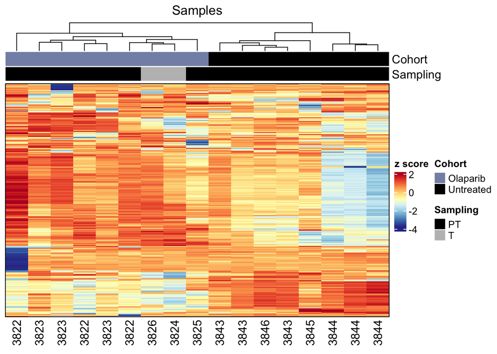

```r
col <- list(Cohort = c("Untreated"="black", "Olaparib"="#8491B4FF"),
            Sampling = c("T"="grey", "PT"="black"))
mypalette <- brewer.pal(11,"RdYlBu")
morecols <- colorRampPalette(mypalette)
ha <- HeatmapAnnotation(Cohort=trial.mdat$Cohort,
                        Sampling=trial.mdat$Sampling,
                        col = col)
Heatmap(var_strong_scaled, top_annotation = ha,
        column_title = "Samples",
        col=rev(morecols(50)),
        border=TRUE, show_row_names =FALSE,
        show_column_names = TRUE,
        clustering_method_columns = "ward.D2",
        name="z score", show_row_dend = F)
```

## Figure 5B

Top 10 significant gene sets by normalised enrichment score, identified by GSEA using the HALLMARK gene sets between untreated and post-treated samples.

### Differential Expression Analysis (DEA)

First we need to perform the differential expression analysis between Olaparib and untreated

```r
group <- factor(trial.mdat$Cohort,
                levels = c("Untreated", "Olaparib" ))
sampling <- factor(trial.mdat$Sampling,
                levels = c("PT", "T" ))
# Remove with 0 expression
trial.expr.clean <- trial.expr[rowSums(trial.expr)!=0,]
# transform ensembl to gene symbol
rownames(trial.expr.clean) <- gene.names.vector[rownames(trial.expr.clean)]
# Normalise with edgeR
y <- DGEList(counts=trial.expr.clean, genes=rownames(trial.expr.clean), group=group)
y <- y[, y$samples$lib.size!="0"]
keep <- filterByExpr(y)
y <- y[keep, , keep.lib.sizes=FALSE]
y <- calcNormFactors(y,method="TMM")
design <- model.matrix(~0+group+sampling, data=y$samples)
rownames(design) <- trial.mdat$`Sample name`
colnames(design) <- c("Untreated", "Olaparib", "samplingT")
#Estimate dispersion between groups
y <- estimateDisp(y, design)
#Testing DE of UT and Olap (T)
fit <- glmQLFit(y, design)
qlf <- glmQLFTest(glmfit = fit, contrast=c(-1,1,0))
# Extract DE genes
is.de <- decideTests(object = qlf, p.value=0.05, adjust.method = "fdr")
```

#### Pathway analysis

First we need to generate a rank

```r
#Get list of most differentially expressed genes
res.top <- as.data.frame(topTags(qlf, n = Inf))
#Rank the genes by logFC
results.ord <- res.top[ order(-res.top[,"logFC"]), ]
# remove duplicates
results.ord <- results.ord[!duplicated(results.ord$genes) & results.ord$genes!="" & !is.na(results.ord$genes),]
# Extract logFC genes ranked
ranks <- results.ord$logFC
names(ranks) <- rownames(results.ord)
#Hallmark gene sets
Hs.H <- geneIds(hallmarks)
# Run pre-ranked GSEA
fgseaRes <- fgsea(Hs.H, ranks, minSize=15, maxSize=500, eps=0)
```

#### Plot

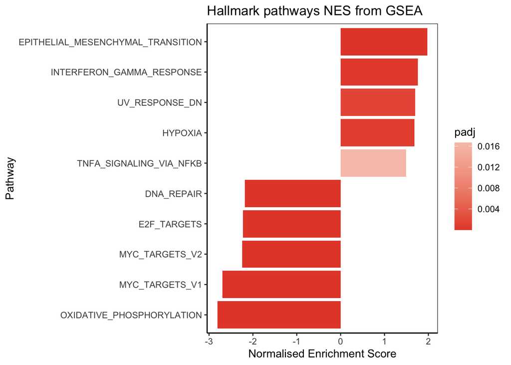

```r
sign <- subset(fgseaRes, fgseaRes$padj<0.05)
ordered <- head(sign[order(padj), ], n=10)
ordered <- ordered[order(-NES), ]
ordered$pathway <- sub(pattern = "HALLMARK_", replacement = "", ordered$pathway )
ggplot(ordered, aes(x=reorder(pathway, NES), y=NES, fill=padj)) +
  geom_col() +
  coord_flip() +
  labs(x="Pathway", y="Normalised Enrichment Score",
       title="Hallmark pathways NES from GSEA") +
  scale_fill_gradient(low = "#E64B35FF", high = "#F39B7F99", na.value = NA) +
  theme_bw() +
  theme(panel.grid.major = element_blank(),
        panel.grid.minor = element_blank(),
        axis.line = element_line(colour = "black"))
```

# Supplementary Figure 3A and 3B: Correlation between PDTC models.

## Supplementary Figure 3A

Principal component analysis of RNA expression data demonstrates that samples separate by PDTX models

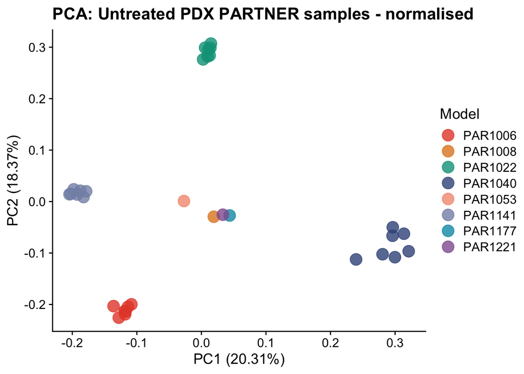

```r
# Colour selection
mypal <- pal_npg("nrc", alpha = 0.7)(8)
names(mypal) <- unique(untreated.mdata$Model)
mypal["PAR1177"] <- "#0099B4B2"
mypal["PAR1221"] <- "#925E9FB2"
mypal["PAR1008"] <- "#E18726B2"
# Principal Component Analysis
pcr <- prcomp(t(untreated.expr.norm))
autoplot(pcr,
         size=5,
         alpha=0.8,
         col="Model",
         data=untreated.mdata) +
  theme_cowplot() +
  ggtitle("PCA: Untreated PDX PARTNER samples - normalised") +
  scale_color_manual(values = mypal)
```

## Supplementary Figure 3B

Heatmap of the correlation between samples (Pearson, Kendall, Spearman) using all genes.

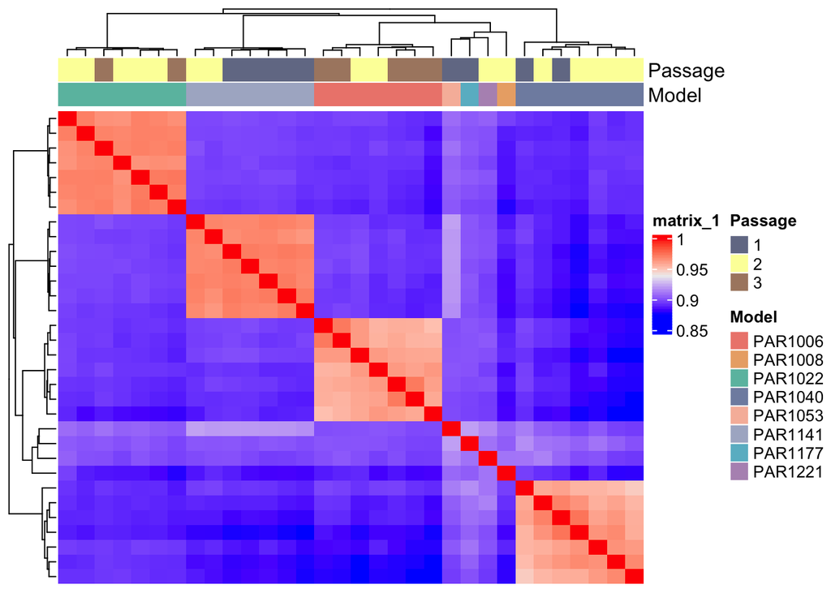

```r
# Colour selection
pas.col <- pal_rickandmorty("schwifty", alpha = 0.7)(3)
names(pas.col)<- unique(untreated.mdata$Passage)
ha <- HeatmapAnnotation(Passage = untreated.mdata$Passage,
                        Model= untreated.mdata$Model,
                        col = list(Model=mypal,
                                   Passage=pas.col))
Heatmap(cor(untreated.expr.norm, method = c("pearson", "kendall", "spearman")), top_annotation =ha, show_row_names = F, show_column_names = F)
```

# Supplementary Figure 8C: BRCA1 expression across PDTX

Normalised gene expression (logCPM) of BRCA1 across PDTX models.

```r
load("data/PAR1022_expression.Rdata")
load("data/PAR1022_metadata.Rdata")
```

Figure shows BRCA1 expression in untreated samples of models: 1006, 1008, 1022, 1040, 1053, 1141, 1177, 1221.

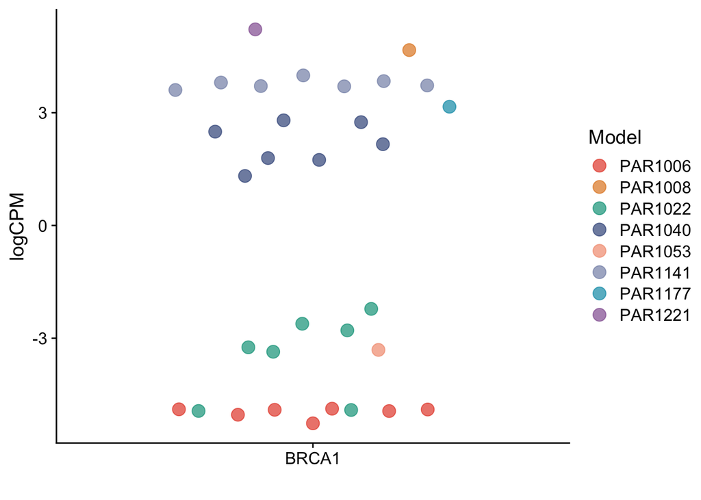

```r
brca1.expr <- untreated.expr.norm["BRCA1",]
stopifnot(names(brca1.expr) == untreated.mdata$`Sample name`)
untreated.mdata$BRCA1 <- brca1.expr
ggplot(untreated.mdata,
       aes(y=BRCA1, x="BRCA1", col=Model)) +
  geom_quasirandom(size=4) +
  scale_color_manual(values = mypal) +
  theme_cowplot() + xlab("") + ylab("logCPM")
```

# Supplementary Figure 10A, 10B and 10C.

## Supplementary Figure 10A: PARP inhibitors

Normalised gene expression (TMM normalised log2CPM) of known PARP inhibitor resistance markers in model 1006 treated in vivo with olaparib. Statistical significance tested between untreated and post-treated tumours using two-tailed unpaired t-test. * p<0.05, ** p<0.01, *** p<0.001, **** p<0.0001.

```r
PARP.inhibitors.markers <- c("BRCA1", "BRCA2", "RAD51", "PALB2", "TP53BP1", "SHLD1", "SHLD2", "SHLD3", "RIF1", "MAD2L2", "DYNLL1", "ATMIN", "PAXIP1", "EZH2", "SLFN11", "PARP1", "PARG", "ABCB1", "ABCG2")
```

```r
group <- factor(trial.mdat$Cohort,
                levels = c("Untreated", "Olaparib" ))
x <- DGEList(counts=trial.expr.clean, genes=rownames(trial.expr.clean), group=group)
x <- x[, x$samples$lib.size!=0]
x <- calcNormFactors(x,method = "TMM")
logcpmtrial <- cpm(x, log=TRUE)
logcpmtrialemt <- logcpmtrial[PARP.inhibitors.markers,]
```

We add gene expression info to metadata

```r
trial.expr.markers.melted <- melt(logcpmtrialemt)
colnames(trial.expr.markers.melted)<-c("Gene", "Sample name", "TMM normalised logCPM")
# we create a copy to not mess with the original metadata
trial.mdat2 <- merge(trial.mdat, trial.expr.markers.melted, by="Sample name", all.x=T)
trial.mdat2$Gene <- factor(trial.mdat2$Gene, levels = PARP.inhibitors.markers)
trial.mdat2$Group <- ifelse(
  trial.mdat2$Gene%in%PARP.inhibitors.markers[1:2], "BRCA reversion",
  ifelse(trial.mdat2$Gene%in%PARP.inhibitors.markers[3:15], "DDR rewiring",
         ifelse(trial.mdat2$Gene%in%PARP.inhibitors.markers[16:17], "Target", "Drug efflux")))
```

Plot

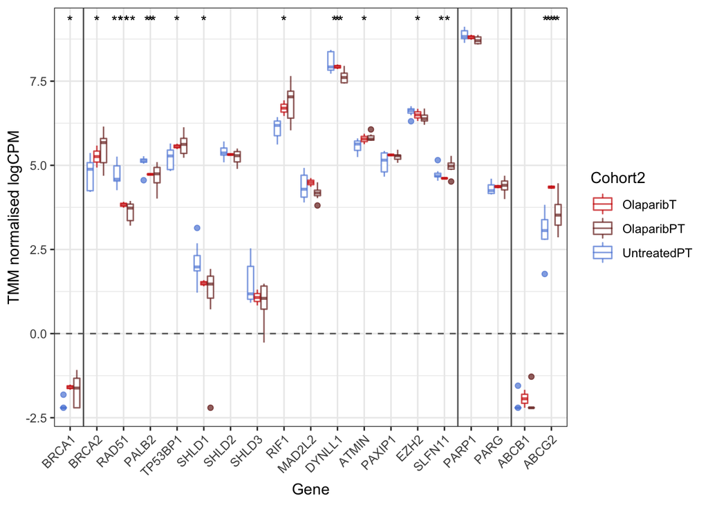

```r
trialcol2 <- c(OlaparibT="#CC0C00B2", OlaparibPT="#75221cB2", UntreatedPT="#5C88DAB2")
trial.mdat2$Cohort2 <- paste0(trial.mdat2$Cohort, trial.mdat2$Sampling)
trial.mdat2$Cohort2 <- factor(trial.mdat2$Cohort2, levels = c("UntreatedPT", "OlaparibT", "OlaparibPT"))
ggplot(trial.mdat2,
       aes(x=Gene, y=`TMM normalised logCPM`, col=Cohort2))+
  geom_boxplot() +
  theme_bw() +
  scale_color_manual(values=trialcol2) +
  theme(axis.text.x = element_text(angle=45, hjust = 1))  +
  geom_hline(yintercept = 0, lty="dashed", col="grey40") +
  geom_vline(xintercept = c(1.5, 15.5, 17.5), col="grey40") +
  stat_compare_means(label =  "p.signif", label.x = 1.5, hide.ns = TRUE, method = "t.test",show.legend = FALSE)
```

## Supplementary Figure 10B: PAR1022

Normalisation

```r
x <- DGEList(counts=par1022, genes=rownames(par1022), group=mdata.1022$Cohort)
x <- x[, x$samples$lib.size!=0]
x <- calcNormFactors(x,method = "TMM")
logcpm1022 <- cpm(x, log=TRUE)
```

Boxplot of BRCA1 expression in PAR1022:

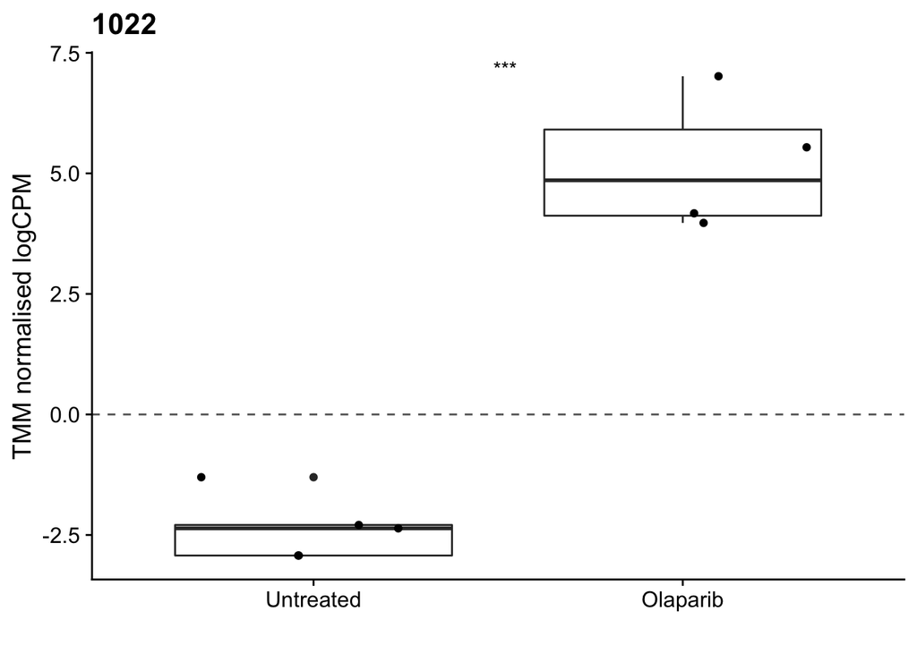

```r
brca1.expr.1022 <- data.table(logcpm1022["BRCA1",])
colnames(brca1.expr.1022)<-"BRCA1"
brca1.expr.1022$`Sample name`<-colnames(par1022)
mdata.1022.brca1<-merge(mdata.1022, brca1.expr.1022, by="Sample name")
mdata.1022.brca1$Cohort <- factor(mdata.1022.brca1$Cohort, levels = c("Untreated", "Olaparib"))
ggplot(mdata.1022.brca1[Sampling=="PT"], aes(Cohort, BRCA1)) +
  geom_boxplot() +
  geom_jitter() + theme_cowplot() + geom_hline(yintercept = 0, lty="dashed", col="grey40")+  stat_compare_means(label =  "p.signif", label.x = 1.5, hide.ns = TRUE, method = "t.test") + ylab("TMM normalised logCPM") + xlab("") + ggtitle("1022")
```

## Supplementary Figure 10C: plotMA

First, we need to perform another DEA

```r
group <- factor(mdata.1022$Cohort,
                levels = c("Untreated", "Olaparib" ))
sampling <- factor(mdata.1022$Sampling,
                levels = c("PT", "HC" ))
y <- DGEList(counts=par1022, genes=rownames(par1022), group=group)
y <- y[, y$samples$lib.size!="0"]
keep <- filterByExpr(y)
y <- y[keep, , keep.lib.sizes=FALSE]
y <- calcNormFactors(y,method="TMM")
design <- model.matrix(~0+group+sampling, data=y$samples)
rownames(design) <- mdata.1022$`Sample name`
colnames(design) <- c("Untreated", "Olaparib", "samplingHC")
#Estimate dispersion between groups
y <- estimateDisp(y, design)
#Testing DE of UT and Olap (T)
fit <- glmQLFit(y, design)
qlf <- glmQLFTest(glmfit = fit, contrast=c(-1,1,0))
```

Mean-difference plot:

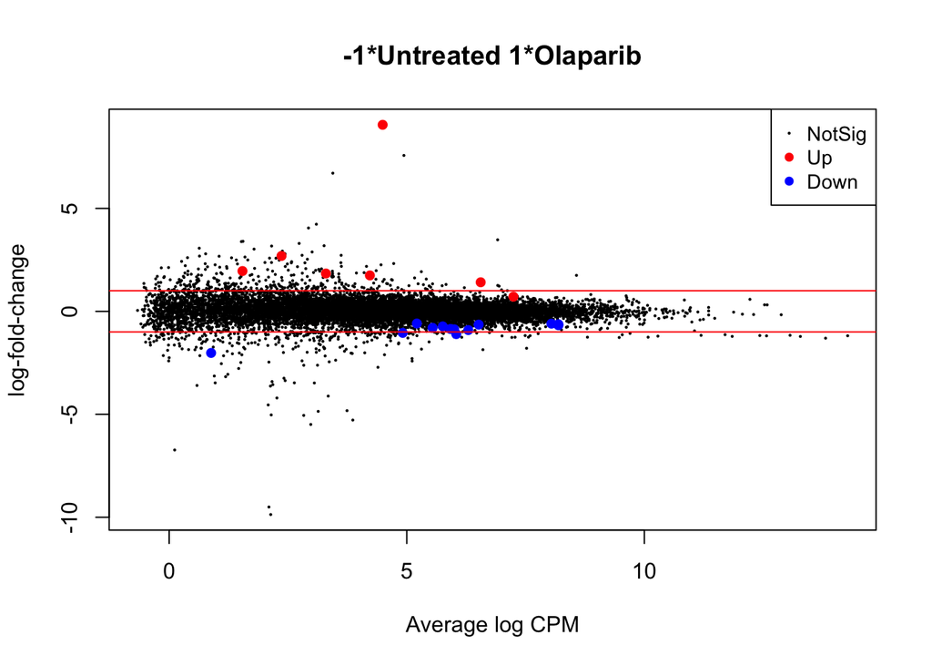

```r
plotMD(qlf)
abline(h=c(-1, 1), col="red")
```

# Supplementary Figure 11A and 11B: EMT

## Supplementary Figure 11A

Enrichment plot of HALLMARK EPITHELIAL MESENCHYMAL TRANSITION gene set following GSEA of olaparib post-treated vs untreated mice from model 1006.

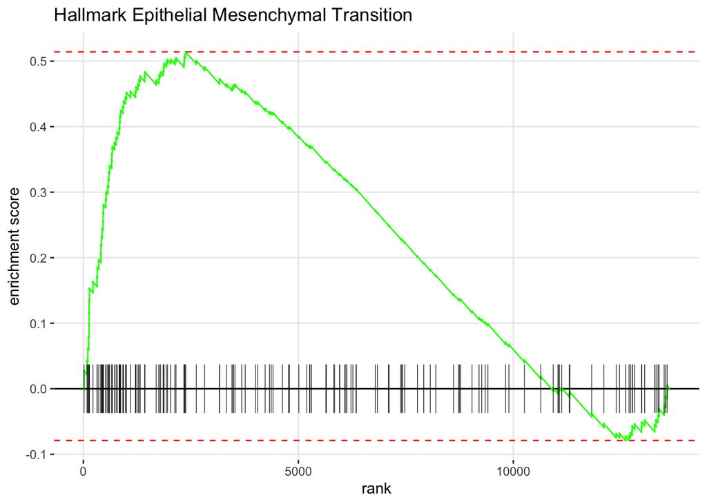

```r
plotEnrichment(Hs.H[["HALLMARK_EPITHELIAL_MESENCHYMAL_TRANSITION"]],
               ranks) + labs(title="Hallmark Epithelial Mesenchymal Transition")
```

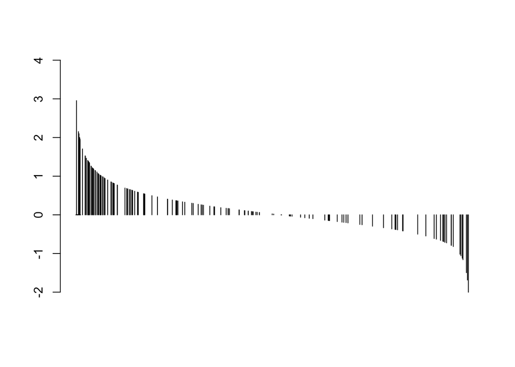

```r
tmpInd <- match(Hs.H[["HALLMARK_EPITHELIAL_MESENCHYMAL_TRANSITION"]],names(ranks))
tmpInd <- tmpInd[!is.na(tmpInd)]
ranks.emt <- ranks[tmpInd]
ranks2 <- rep(0,length(ranks.emt))
ranks2[tmpInd] <- ranks[tmpInd]
barplot(ranks2, ylim = c(-2, 4))
```

## Supplementary Figure 11B

Normalised gene expression (TMM normalised log2CPM) of epithelial and mesenchymal markers in model 1006 treated in vivo with olaparib. All genes were found to be differentially expressed between untreated and post-treated samples. Statistical significance tested between untreated and post-treated tumours using two-tailed unpaired t-test. * p<0.05, ** p<0.01, *** p<0.001, **** p<0.0001.

```r
em.markers <- c("EPCAM", "MUC1", "KRT8", "KRT18", "KRT81", "KRT86", "CLDN3", "CLDN4", "TGFBI", "IGFBP2", "SNAI2", "FN1")
logcpmtrialem <- logcpmtrial[em.markers,]
trial.expr.em.markers.melted <- melt(logcpmtrialem)
colnames(trial.expr.em.markers.melted)<-c("Gene", "Sample name", "TMM normalised logCPM")
# we create a copy to not mess with the original metadata
trial.mdat.em <- merge(trial.mdat, trial.expr.em.markers.melted, by="Sample name", all.x=T)
trial.mdat.em$Gene <- factor(trial.mdat.em$Gene, levels = em.markers)
trial.mdat.em$Group <- ifelse(
  trial.mdat.em$Gene%in%em.markers[1:8], "Epithelial markers",
  ifelse(trial.mdat.em$Gene%in%em.markers[9:12], "Mesenchymal markers", ""))
trial.mdat.em$Cohort2 <- paste0(trial.mdat.em$Cohort, trial.mdat.em$Sampling)
trial.mdat.em$Cohort2 <- factor(trial.mdat.em$Cohort2, levels = c("UntreatedPT", "OlaparibT", "OlaparibPT"))
```

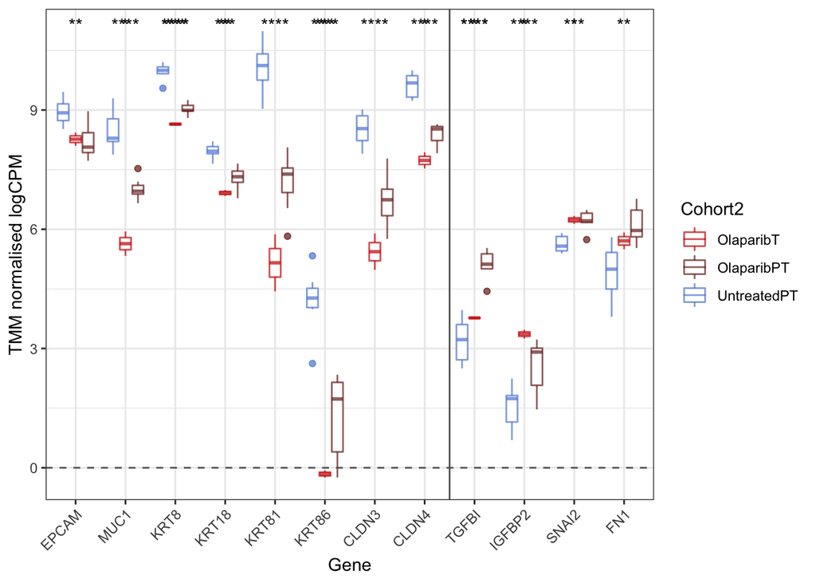

```r
ggplot(trial.mdat.em,
       aes(x=Gene, y=`TMM normalised logCPM`, col=Cohort2)) +
  geom_boxplot() +
  theme_bw() +
  scale_color_manual(values=trialcol2) +
  theme(axis.text.x = element_text(angle=45, hjust = 1))  +
  geom_hline(yintercept = 0, lty="dashed", col="grey40") +
  geom_vline(xintercept = c(8.5), col="grey40") +
  stat_compare_means(label =  "p.signif", label.x = 1.5, hide.ns = TRUE, method = "t.test", show.legend = F)
```

The end.